# Homework #8

**See Canvas for the HW #8 assignment and due date**. Complete all of the following problems. Ideally, the theoretical problems should be answered in a Markdown cell directly underneath the question. If you don't know LaTex/Markdown, you may submit separate handwritten solutions to the theoretical problems, but please see the [class scanning policy](https://docs.google.com/document/d/17y5ksolrn2rEuXYBv_3HeZhkPbYwt48UojNT1OvcB_w/edit?usp=sharing). Please do not turn in messy work. Computational problems should be completed in this notebook (using the R kernel). Computational questions may require code, plots, analysis, interpretation, etc. Working in small groups is allowed, but it is important that you make an effort to master the material and hand in your own work.

## B. Computational Problems

## B.1 Do remote students perform worse?

In spring 2019, STAT 5010 had two sections: an in-person section and an online/remote section. The Department of Applied Math is interested to know whether the in-person students performed better than the remote students. For this question, let $\alpha = 0.05$.

Each row of the dataset is a student from STAT 5010 in 2019. The variables in the dataset are:

- `modality`: `1` denotes in-person, `2` denotes remote.
- `score`: The final score in the class.

```r
library(tidyverse)
library(ggplot2)


df = read.csv(url(paste0("https://raw.githubusercontent.com/bzaharatos/STAT-5000/main/data/InPersonRemote.txt")), sep="\t")
df$modality = as.factor(df$modality)
summary(df)
dim(df)
```

```
     score       modality
 Min.   :74.64   1:13
 1st Qu.:79.15   2:19
 Median :80.69
 Mean   :80.99
 3rd Qu.:82.04
 Max.   :87.84
```

1. 32

2. 2

**B.1 (a) [10 points] Explore the data to decide whether the normality and equal variance assumptions might be violated.**

If you do not have evidence that the data are non-normal, you can carry on as if the data are normal. If you're not sure whether the variances are equal, assume they aren't.

```
In person Variance:  11.24063
Remote Variance:  5.111162
In person mean:  82.16154
Remote mean:  80.19211
```

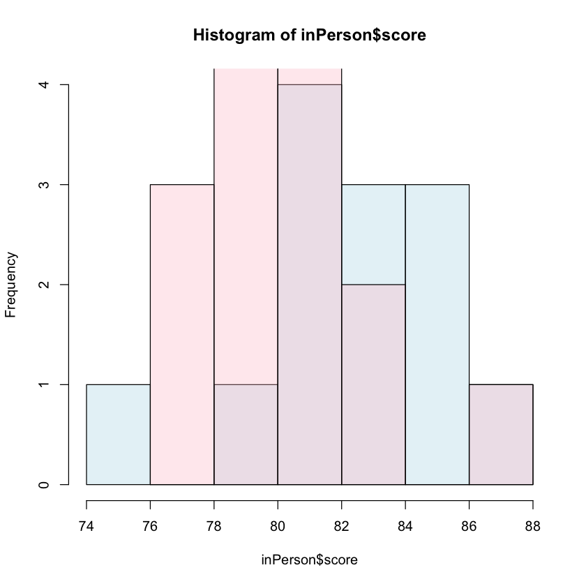

```r
c1 <- rgb(173,216,230,max = 255, alpha = 80, names = "lt.blue")
c2 <- rgb(255,192,203, max = 255, alpha = 80, names = "lt.pink")

inPerson = df[df$modality == 1, ]
remote = df[df$modality == 2, ]

inP <- hist(inPerson$score, plot=FALSE)
re <- hist(remote$score, plot=FALSE)

plot(inP, col = c1)
plot(re, col = c2, add=TRUE)

cat("In person Variance: ",var(inPerson$score), '\n')
cat("Remote Variance: ", var(remote$score), '\n')

cat("In person mean: ",mean(inPerson$score), '\n')
cat("Remote mean: ", mean(remote$score))
```

In whole data has seems to have a normal distribution, therefore I believe there is normality. However, when the data is split by each modality it seems like we can not assume equal variance. Especially when the variance for each group is printed.

Let $\mu_R$ represent the population mean of scores in the **r**emore group. Let $\mu_P$ represent the population mean of scores in the in-**p**erson group.

**B.1 (b) [10 points] Test whether there is statistical evidence that $\mu_R \ne \mu_P$ at the $\alpha = 0.05$ level. Use the appropriate test, based on the results from B.1(a). Code the test yourself (without using a built-in R function). Be sure to write out your null and alternative hypotheses and clearly state your decision.**

We'll assume that no other variables would be relevant to any difference in scores (but that's probably not true, and we learn how to deal with this kind of situation in STAT 5010!).

```r
nx = length(remote$score); ny = length(inPerson$score);
xbar = mean(remote$score); ybar = mean(inPerson$score);
vX = var(remote$score); vY = var(inPerson$score);

#Delta
delta = 0

#Welch
t = (xbar - ybar - delta)/sqrt((vX/nx + vY/ny));
v = ((vX/nx + vY/ny)^2/((vX/nx)^2/(nx -1) + (vY/ny)^2/(ny-1)))
p = 2*(1-pt(abs(t), v));
p
```

0.0796711741883556

**B.1 (c) [10 points] Now find an R function that conducts the test that you used in B.1(b). Interpret the confidence interval given by that function.**

```r
t.test(remote$score,inPerson$score, var.equal = FALSE, alternative = 'two.sided')
```

```
	Welch Two Sample t-test

data:  remote$score and inPerson$score
t = -1.8497, df = 19.378, p-value = 0.07967
alternative hypothesis: true difference in means is not equal to 0
95 percent confidence interval:
 -4.1950236  0.2561572
sample estimates:
mean of x mean of y
 80.19211  82.16154
```

The CI given means the $95\%$ CI that the difference in mean exam scores between the 2 groups is (-4.19, 0.25)

## B.2 Parametric tests without normality

Let $X ∼ P(\lambda)$. We want to test the null hypothesis that $\lambda \leq 15$, and the alternative hypothesis is that $\lambda > 15$. Our sample size for this test is equal to 1. We will reject the null hypothesis if $X$ is greater than a certain value $c$.

**B.2 (a) [18 points] What value should we choose for $c$ such that the probability of a type I error is at most $0.10$? In the first cell, write out the relevant formulas. In the second (code cell), construct a table of values for $c$ along with the corresponding type I errors. In the third, state $c$.**

$H_0: \lambda \leq 15$ and $H_1: \lambda > 15$ So our formula is: $$ \alpha = \underset{\theta \in H_0}{max}\hspace{0.5em}P(\hspace{0.3em}reject \hspace{0.5em}H_0; \lambda \leq 15) \\ \alpha = \underset{\theta \in H_0}{max}\hspace{0.5em}P(X > c, \lambda \leq 15) $$

```r
alpha = c(0.01, 0.25, 0.075, 0.1, 0.15, 0.2, 0.25, 0.5, 0.75)

z = cbind(alpha, replicate(1, qpois(1-alpha, 15)))
z
```

| alpha |  |
| --- | --- |
| 0.010 | 25 |
| 0.250 | 18 |
| 0.075 | 21 |
| 0.100 | 20 |
| 0.150 | 19 |
| 0.200 | 18 |
| 0.250 | 18 |
| 0.500 | 15 |
| 0.750 | 12 |

So the value we should choose for $c$ to have a type I error at most $0.10$ is $c = 20$

**B.2 (b) [6 points] If $\lambda$ is actually equal to $20$, what is the probability of making a type 2 error using the cut-off point from B.2 (a)? In the first cell, write the appropriate formula. In the second, calculate it using R.**

For type II error our formula is: $$ \beta = P(Fail\hspace{0.3em}to\hspace{0.3em}Reject H_0; \lambda > 15) $$ Which is also: $$\beta = P(X < c; \lambda > 15)$$ In terms of power (the probaility we reject the null hypothesis when the null is false): $$ Power = 1 - \beta $$ Therefore to find beta: $$ \beta = 1 - Power$$

```r
lbda = 20; alpha = 0.1; c = 20;
power = ppois(c, lbda, lower.tail=FALSE)

beta = 1 - power
beta
```

0.559092584231325

## B.3 Severely tested claims?

Let $X$ be the number of heads in $n = 60$ tosses of a coin. Denote the probability of heads as $p$. In this example, we will explore properties of a test of whether the coin is biased toward heads.

**B.3(a) [7 points] Explicitly write out the null and alternative hypotheses. Let the parameter space be all $p \in (0,1)$.**

The null hpyothesis is the probability that the coin is fair or unbiased towards heasds is: $H_0: p \leq 0.5$. The alternative hypothesis is the probability the coin is biased towards heads $H_1: p > 0.5$.

**B.3(b) [5 points] Define the rejection region to be $X \ge 37$. Calculate the rate of type I error. (For this part, and all remaining parts, calculate probabilities exactly, i.e., without using the normal approximation).**

```r
n = 60; p = 0.5;
x=1-pbinom(36, n, p)
x
```

0.0462304905364621

**B.3(c) [10 points] Construct a grid of values for $p$ under the alternative hypothesis. For each value of $p$ in this grid, calculate the power of this test (remember that statistical power is the probability of rejecting the null hypothesis while an alternative hypothesis is true). Make a plot of the power ($y$-axis) vs $p$ ($x$-axis). Interpret/comment on this plot. In particular, as $p$ gets further from the $p$ specified under the null hypothesis, what happens to the power?**

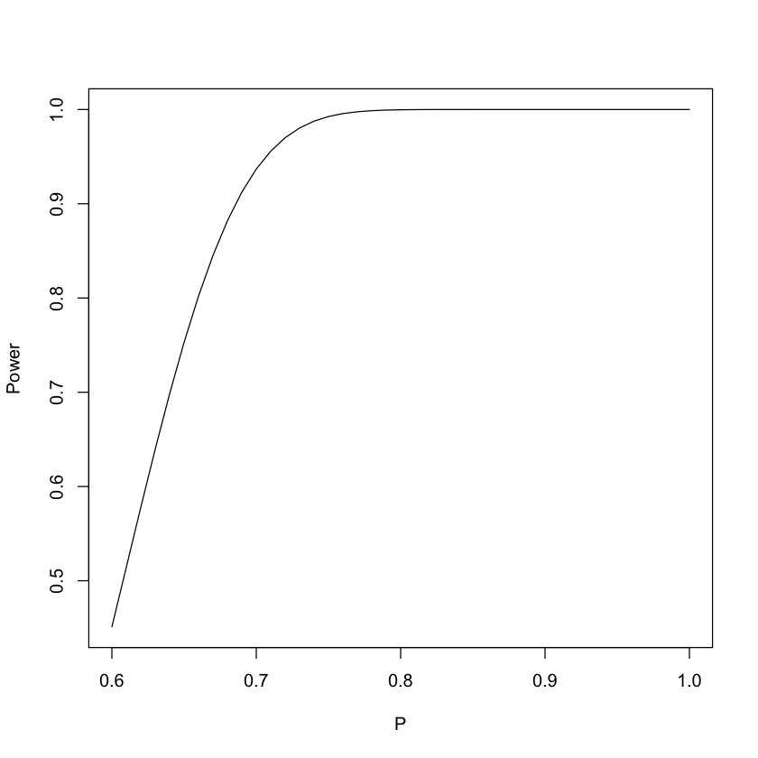

```r
pAlt = seq(0.6,1, 0.01)
pow = 1-replicate(1, pbinom(36,n,pAlt));
plot(pAlt, pow, type='l', xlab= 'P', ylab = 'Power')
```

As the probability of $p$ increases the power increases. That means the probility we reject $p$ bieng biased towards tails when the null is false increases to $1$.

**B.3(d) [6 points] Suppose that you flip the coin and get $27$ heads out of $60$. Use this information to test your hypotheses from part B.3(a). State your conclusion.**

```r
pbinom(27, n, p)
1 -pbinom(27, n, p)
```

0.259479001594827

0.740520998405173

At this point, we've failed to reject $H_0$. But do we have evidence that the coin is fair, or close to fair? Typical "classical" frequentist inference stops with p-values calculated on tests with reasonable error properties (e.g., low type I error and high power). But philosopher Deborah Mayo developed an extension to hypothesis testing, called *severity*, that claims to, among other things, help justify claims about "accepting" $H_0$.

Instead of merely concluding that we have no evidence that $p>0.5$", we can use the observed result `x` to assess specific inferences about $H_0$.

Severity is meant to answer the question *what is the probability of a worse fit with a claim $C$ if $C$ were false?* We can think of severity as a function of three items: a test $T$ (e.g., a specified statistical model, null, and alternative hypotheses), an outcome $O$ (e.g., an $\bar{x}$, $\widehat p$), and a claim $C$, (e.g., $p < 0.5$).

- For this test, a "worse fit" would mean that the observed $x$ would be such that $x/n$ is further from the claim $C$. So, for the claim $C: p < 0.5$, a worse fit would be anything greater than $x = 27$.
- "If $C$ were false" means that we evaluate the relevant probability under the complement of $C$. We choose the value of $p$ that is the smallest pertubation to make $C$ false. So, for the claim $C: p < 0.5$, we would use $p = 0.5$ to make $C$ false.

According to Mayo, severity can be thought of as a measure of how severely tested a claim is. In particular, if $H_0$ has a high severity value, then $H_0$ is severely tested, and has some corroboration.

**B.3(e) [11 points] Compute the severity of $C: p < 0.5$? Is $H_0$ severely tested?**

```r
n = 60; p =0.5; pHat = 27/n
z = (pHat - p)/sqrt(p*(1- p)/n)
pVal = pnorm(z)
pVal
```

0.2192890130405

$$ P(p > 0.45; C^c) = P(p > 0.45; p = 50) $$

**B.3 (f) Compute the severity for all values of $p$ between $0$ and $0.5$. Comment on the shape of the curve.**

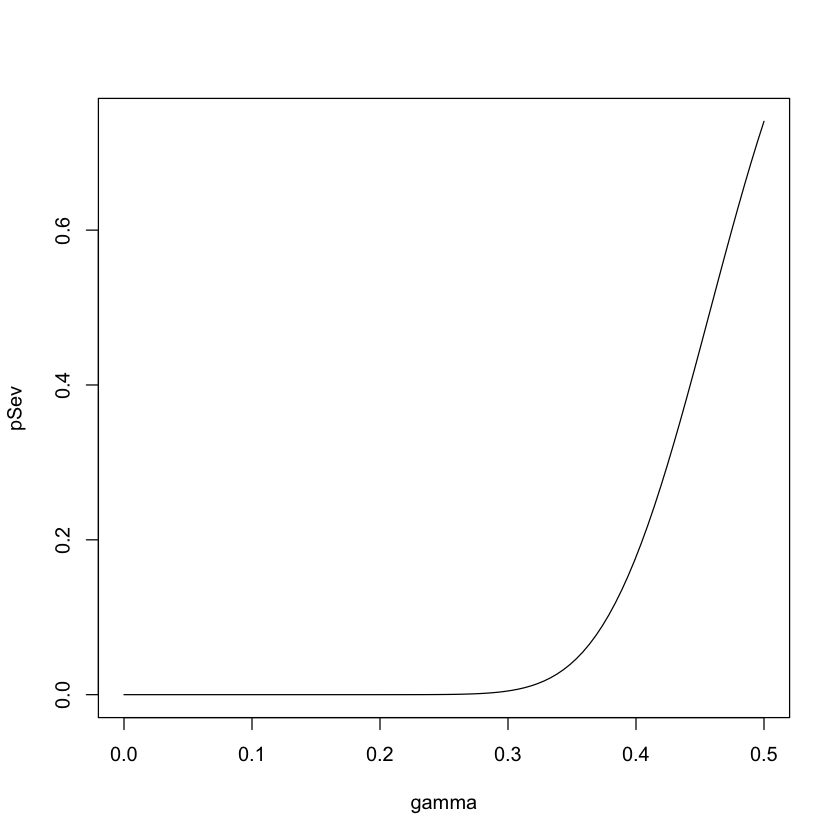

```r
gamma = seq(from = 0, to =0.5, length = 100)
pSev = 1- pbinom(27, 60, gamma)
plot(gamma, pSev, type="l")
```

It looks like an exponential curve that converges towards $0.5$

**B.3 (g) [5 points] Now compute the severity for $H_1: p > 0.5$, using the same $x = 27$ as above. Note that "a worse fit" and "$C$ is false" will have different interpretations. Plot the severity against $(0.5, 1)$.**

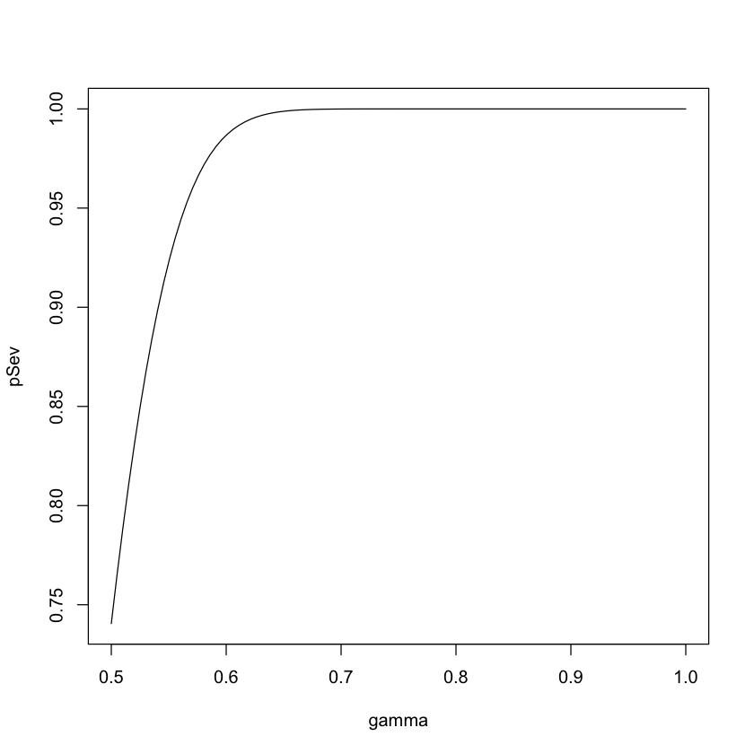

```r
gamma = seq(from = 0.5, to =1, length = 100)
pSev = 1- pbinom(27, 60, gamma)
plot(gamma, pSev, type="l")
```

Let $\gamma$ be the discrepancy from the null hypothesis (e.g., so in this problem, $\gamma = 0.1$ corresponds to $p = 0.6$). One unfortunate consequence of hypothesis testing is the [paradox of large samples](https://www.jstor.org/stable/24093874?seq=1#metadata_info_tab_contents): the larger the sample size, $n$, the smaller the $\gamma$ necessary for rejecting $H_0$. In the extreme, that means that very large samples will reject the null hypothesis when $\gamma$ is very close to zero. But some argue that that should be evidence *for* the null.

Severity is thought to help solve this problem; it would help solve the problem if for a fixed observation (e.g., $\widehat p$), for larger samples, small deviations from the null hypothesis were tested less severely.

**B.3 (g) [7 points] Now, let $x = 180$ and $n = 400$ (up from $60$ above). So, $\widehat p$ is the same, but the sample size is bigger. Show that the severity curve decays more steeply, giving lower severity to small values of $\gamma$ when compared to the smaller sample. Describe how these plots help solve the paradox of large samples.**

0.0227501319481792

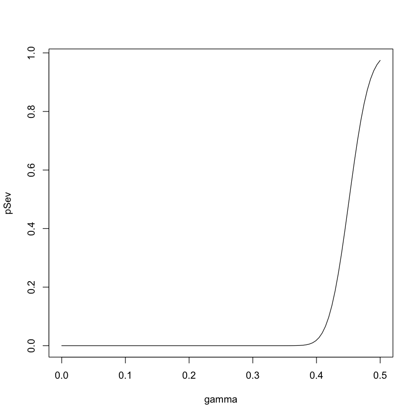

```r
n = 400; p =0.5; pHat = 180/n
z = (pHat - p)/sqrt(p*(1- p)/n)
pVal = pnorm(z)
pVal

gamma = seq(from = 0, to =0.5, length = 100)
pSev = 1- pbinom(180, 400, gamma)
plot(gamma, pSev, type="l")
```

The plots show us how easily the data is pertibated from different sample sizes.